# rando

Ian McDonald

2/21/2022

**Run these commands first**

```r
knitr::opts_chunk$set(message = FALSE, warning = FALSE)
suppressMessages(library(tidyverse))
my_sample <- function(n = 1) sample(population, n)
```

This simple introduction to margin of error uses the concept of population and sample as discussed before.

Statistics requires the practice of taking a sample from a population. To understand what a margin of error means, assume that we are taking a reliable sample from a population that captures some kind of opinion measure, using a yes-or-no question. It doesn’t matter what question, so let’s use “Biden Job Approval yes/no” to start,

Let’s define our population as ten million people who all have an opinion of either yes or no. We know we can’t ask all ten million people, but we can ask a sample of them. Suppose a realistic sample size is 1000.

In our first example, we will play God with our population and define it to have a known percentage of approval: say 45% approve, and 55% disapprove.

Computer applications all have a powerful capability to make random draws from populations defined in the application. It’s easy to demonstrate in R, and slightly harder to demonstrate in a spreadsheet, but still possible.

**Step 1: Log into RStudio/cloud and find the Margin of Error Demo project. If you need the link to share the workspace, see https://bit.ly/35Zmixt**

**Step 2: Open up a new R File Script (File/New File), save it as “MOE Demo”, and paste the content in this box into the editor.**

```r
percent_yes <- 45

ex <- 1e5
population <- c(rep(1,percent_yes * ex), rep(0, (100 - percent_yes) * ex))
```

In this section, you have created a data object called population. Population contain 10 million values of either 1 (Approval) or 0 (disapproval). Exactly 45% of the values contain 1.

In this exercise, you will make random draws from Population. You’ll use a command called my_sample(), where you will insert the size of the draw into the parentheses.

**Step 3. Load the my_sample() command as you see it below. In this format, it defaults to one randome draw. Run it repeatedly 5 - 10 times.**

```r
my_sample()
```

```
## [1] 1
```

Notice that you see the display report 0 and 1 intermittently. R is making random draws of 1 from the population data object. If you ran it 100 times, how often would you expect to see 1?

**Step 4: Increase the size of the draw by entering my_sample(100). You’ll see a random selection of 100 0’s and 1’s. Run it again, and the positions of the 1’s and 0’s. will change.**

**Step 5: Run the sum(my_sample(100)) command. Repeat that 5 or 10 times.**

```r
my_sample(100)
```

```
##   [1] 0 0 0 0 1 1 1 0 1 0 0 1 0 1 1 0 1 0 1 1 0 1 0 0 1 0 0 1 1 1 1 1 0 1 1 1 0
##  [38] 1 1 1 0 0 0 1 1 0 0 1 0 0 1 1 0 0 0 0 1 1 0 1 0 1 0 0 0 1 1 0 0 1 1 0 1 1
##  [75] 1 1 0 1 0 1 1 1 1 0 0 0 1 0 0 1 1 1 0 1 0 1 0 1 0 1
```

```r
sum(my_sample(100))
```

```
## [1] 46
```

You should see sum results in the neighborhood of 45, with various values not too far from it.

**Step 6: Try the same thing with samples of 1000.**

```r
my_sample(1000)
```

```
##    [1] 1 0 1 1 0 1 1 1 0 0 0 0 0 0 1 1 1 0 1 1 1 1 1 1 0 0 1 0 0 1 1 1 1 1 0 0 0
##   [38] 0 0 1 0 0 0 0 0 1 0 1 0 1 1 0 0 0 0 0 0 1 1 0 0 0 0 0 1 1 0 1 1 1 1 0 1 1
##   [75] 1 0 0 0 0 1 1 1 1 1 1 0 1 1 1 0 1 1 0 1 0 1 0 1 1 1 0 1 0 1 1 0 0 0 0 1 0
##  [112] 1 0 1 0 0 0 0 1 1 1 0 0 0 1 1 1 1 0 0 1 0 0 0 0 0 0 1 0 1 1 1 1 1 0 1 1 0
##  [149] 1 1 0 1 1 0 0 1 0 0 1 0 0 0 0 0 1 1 0 1 1 1 0 1 1 0 0 0 1 0 0 1 0 1 0 0 0
##  [186] 0 0 1 0 0 1 0 1 1 0 1 0 0 0 1 0 0 0 0 1 1 1 1 0 1 1 1 1 0 0 0 1 1 0 1 0 0
##  [223] 0 1 0 0 1 1 0 0 0 0 1 1 1 0 0 1 0 0 0 1 1 1 0 0 1 1 1 1 1 1 1 1 0 1 1 0 0
##  [260] 1 1 1 1 1 1 0 1 0 1 0 0 1 0 0 0 0 0 1 1 0 1 0 0 0 0 1 1 1 1 1 1 1 0 0 0 1
##  [297] 1 0 1 0 0 0 0 1 0 0 0 0 0 1 0 0 1 0 0 1 1 0 0 1 0 0 0 1 0 1 1 1 1 1 1 1 0
##  [334] 0 0 1 1 1 0 0 1 1 0 1 1 0 0 0 0 0 1 1 0 0 1 0 1 0 0 0 0 0 0 0 0 0 0 1 0 1
##  [371] 0 0 0 1 1 1 0 0 1 0 1 0 0 0 0 0 1 1 0 0 0 1 1 1 0 1 0 1 0 1 1 1 0 0 1 1 1
##  [408] 1 1 0 0 0 0 1 1 0 0 1 0 0 0 0 1 0 1 1 1 1 0 0 1 1 0 0 1 1 1 1 0 0 0 1 1 0
##  [445] 0 1 1 1 0 1 0 0 0 1 1 0 0 0 1 1 0 1 1 0 0 1 0 1 1 1 1 0 0 0 0 0 1 0 0 1 0
##  [482] 1 0 1 1 1 1 1 0 1 1 0 0 0 0 1 0 0 1 1 0 0 0 1 0 0 1 1 1 1 0 1 0 0 1 0 1 0
##  [519] 0 1 1 0 1 0 1 1 0 0 0 0 1 0 1 0 1 0 0 1 0 0 0 0 1 1 1 0 0 0 0 0 1 1 1 0 1
##  [556] 1 0 0 0 1 0 0 0 0 1 0 0 1 0 1 0 1 0 0 1 0 0 0 0 1 1 1 0 0 0 1 0 1 1 1 0 1
##  [593] 0 0 1 0 0 0 1 0 1 0 1 0 0 1 1 1 0 1 0 0 0 0 1 1 0 0 0 1 0 0 1 1 1 0 0 0 1
##  [630] 1 1 1 1 0 1 1 0 1 0 1 1 0 0 0 0 0 0 1 0 1 0 0 0 1 1 0 0 0 1 0 1 1 0 1 1 1
##  [667] 0 0 1 0 1 0 0 1 1 1 1 1 1 0 1 0 0 0 1 0 0 1 1 1 0 0 1 1 0 0 0 0 0 1 0 0 1
##  [704] 0 0 1 0 1 1 0 1 0 1 0 1 1 0 1 1 1 1 0 1 1 1 1 1 0 0 1 1 0 0 0 1 0 1 0 1 1
##  [741] 1 1 0 0 0 1 0 1 0 0 1 1 1 0 0 0 1 0 0 1 1 1 0 0 0 0 0 1 0 0 0 0 1 0 0 0 1
##  [778] 0 1 0 1 1 0 1 0 0 0 0 0 0 1 1 1 1 0 0 1 1 0 1 1 0 1 0 1 0 0 1 0 0 0 0 0 0
##  [815] 0 0 0 1 1 0 1 0 0 0 0 0 0 1 0 0 0 0 0 0 1 1 0 0 0 1 0 1 1 0 1 1 1 0 0 0 0
##  [852] 1 0 0 0 1 0 1 0 1 1 1 1 0 1 1 0 0 0 0 1 0 0 1 1 0 1 0 0 1 1 1 0 1 0 1 1 0
##  [889] 0 0 0 0 1 1 0 0 0 1 0 1 0 0 0 1 0 0 0 1 0 1 1 0 0 0 1 0 0 0 0 0 0 1 0 0 0
##  [926] 0 1 0 1 0 0 1 0 0 1 1 0 1 0 1 0 0 0 0 0 0 0 1 0 1 0 1 0 1 1 0 1 1 1 1 1 1
##  [963] 1 1 0 0 0 0 0 0 1 1 0 1 1 0 0 0 0 1 0 1 1 0 0 1 0 1 1 1 0 0 1 1 1 1 0 0 1
## [1000] 1
```

```r
sum(my_sample(1000))
```

```
## [1] 436
```

You generated a mean of a sample with 1000 values. What if we repeat that process 1000 times?

**Step 7: Run this code which will take a few seconds.**

```r
x <- rep(0, 1000)
for(i in 1:1000) x[i] <-sum(my_sample(1000))
```

We now have a data object called “x” with 1000 repetitions of the Biden approval fractions of 1000.

**Step 8: Run this code. What is the smallest and what is the largest value we constructed? Why aren’t they exactly 450?**

```r
min(x)
```

```
## [1] 404
```

```r
max(x)
```

```
## [1] 498
```

**Step 9: Finally, let’s build a histogram with some R trickeration**

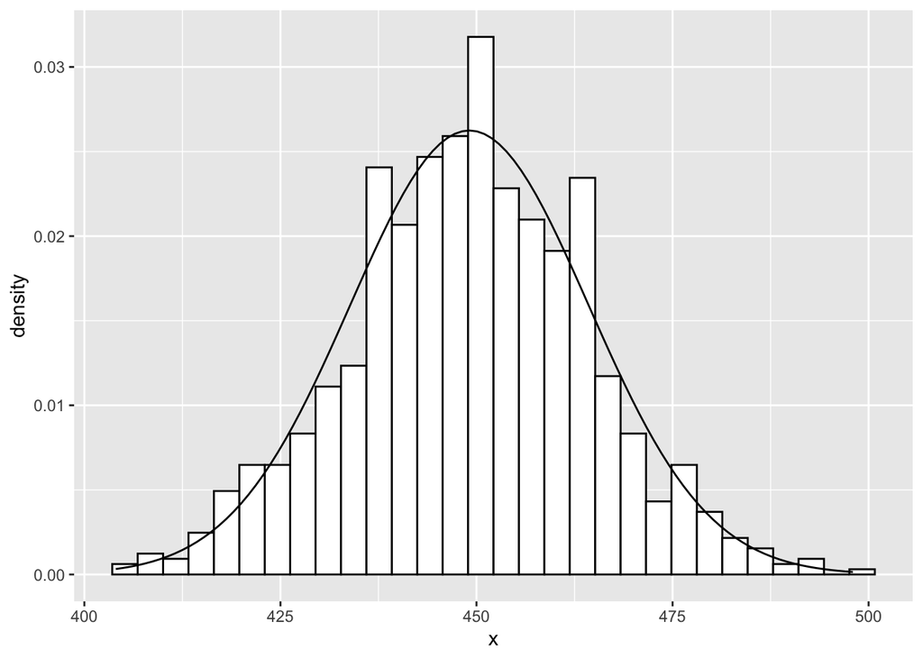

```r
x <- as.data.frame(x)

ggplot(x, aes(x = x)) +
  geom_histogram(aes(y =..density..),
                 colour = "black",
                 fill = "white",
                 bins = 30) +
  stat_function(fun = dnorm, args = list(mean = mean(x$x), sd = sd(x$x)))
```

This particular histogram has a normal curve superimposed over the top of it, and you can see the histogram has some flavor or a normal curve but not perfectly so.

But the important point is the repeated processes of a 1000 samples hugs around 450 (45% of 1000) but often varies from it. Some are lower than 420 and some are greater than 480. In fact, we can determine which values comprise the middle 95% of all the ones we generated.

**Step 10: Run this code.**

```r
The_fives <- quantile(x$x, c(.025,.975))
The_fives
```

```
##    2.5%   97.5%
## 418.000 479.025
```

What does this tell us?

In this example, we enjoy the artificial benefit of knowing the population contains 45% approve. The population is so large that increasing it doesn’t change our analysis, and we know we can’t survey everyone in it,

So, instead, we draw a perfect random sample of 1000 as we conduct a poll. As you can see from running this sample 1000 times, we generate a range of possible values based on our random draw. Repeating the process 1000 times means “run the survey 1000 times” which we could never do in real life. This is just a simulation, But had we done this, we would have generated a distribution.

You see the distribution in the histogram. You see lots of times when the survey gives a result near 450, the result we expect, but rarely does the result hit 450 on the nose. Sometimes it does, and sometimes it’s a bit greater and a bit less. Once in a while, the result is less than 420 and greater than 482.

If you’re wondering “why would you run a survey if you know the population percentage”, we’re doing it to prove a point,

Imagine that we run a single survey and we get a result of 430. We would know that the potential survey was greater than 102 of the trials and less than 898 of the trials. A little bit of an outlier but in the range of a plausible outcome.

If we didn’t have the benefit of a 1000 trials, and the perfect knowledge the answer is 45%, we can still imagine there is a limited range of plausible values the population could have given our survey result of 43%. One potential value is 45%, but we also have some formulas that tell us the range of all plausible values. **In fact, the range goes from 39.9 to 46.1.**

What would that range mean if our survey said 43%? It means that a population anywhere within that range could produce a 43% survey easily. Our survey would be part of the hypothetical results any of those populations would produce 95% of time. The range captures and idea called our confidene interval, based on a presumed confidence level of 95%. Our margine of error is +/- 3.1.

The margin of error tells us that the population values with the range it defines are plausible. Our survey would have part of those population’s bundle of surveys achievable 95% of the time.

A lot of value lie outside that range of plausibility. We wouldn’t ever see 13% or 82%, as a practical matter.